# Day 3: Descriptive Stats

Project:Write an R script to perform descriptive statistics on a dataset

For this project, I will use the iris dataset, as it is easily accessable.

I will first want to look at a brief summary of the data set:

```r
summary(iris)
```

```
  Sepal.Length    Sepal.Width     Petal.Length    Petal.Width          Species
 Min.   :4.300   Min.   :2.000   Min.   :1.000   Min.   :0.100   setosa    :50
 1st Qu.:5.100   1st Qu.:2.800   1st Qu.:1.600   1st Qu.:0.300   versicolor:50
 Median :5.800   Median :3.000   Median :4.350   Median :1.300   virginica :50
 Mean   :5.843   Mean   :3.057   Mean   :3.758   Mean   :1.199
 3rd Qu.:6.400   3rd Qu.:3.300   3rd Qu.:5.100   3rd Qu.:1.800
 Max.   :7.900   Max.   :4.400   Max.   :6.900   Max.   :2.500
```

For further exploration, I will open the dplyr and ggplot2 libraries for more functions

```r
library(dplyr)
library(ggplot2)
```

Next I want to explore the distribution of the variables

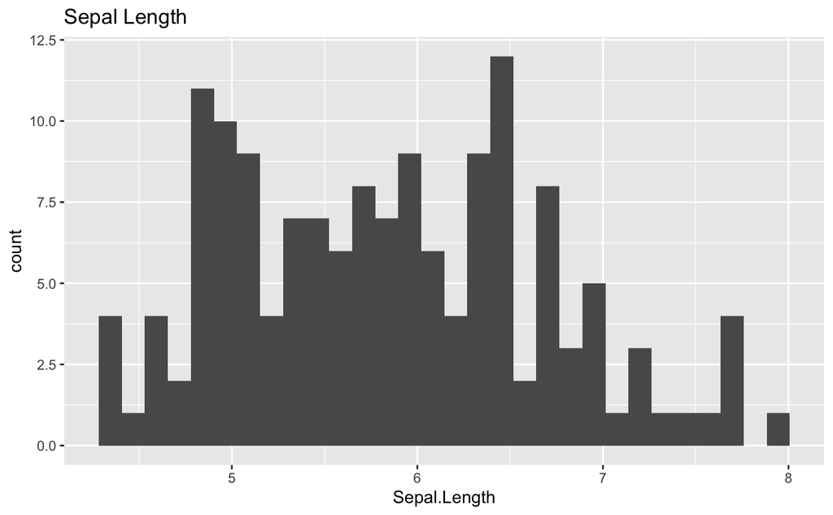

```r
ggplot(data, aes(Sepal.Length)) +
  geom_histogram() +
  labs(title = "Sepal Length")
```

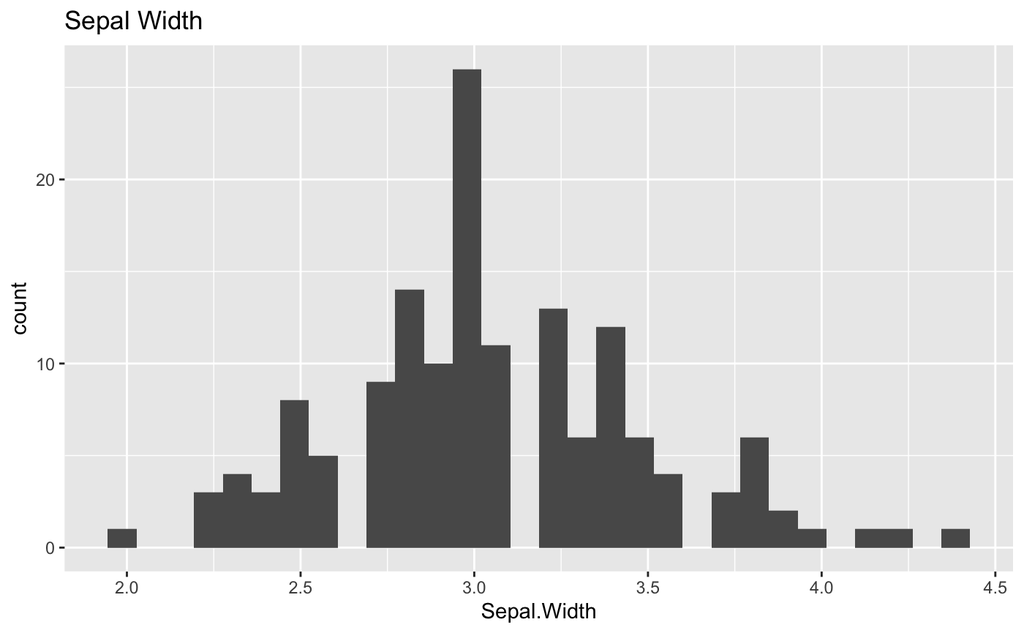

```r
ggplot(data, aes(Sepal.Width)) +
  geom_histogram() +
  labs(title = "Sepal Width")
```

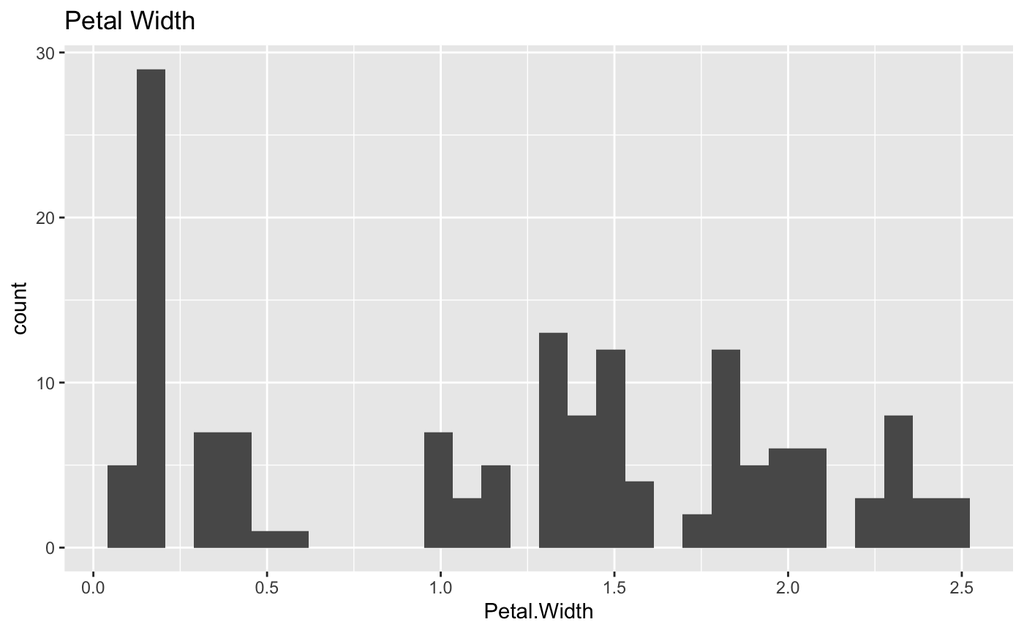

```r
ggplot(data, aes(Petal.Width)) +
  geom_histogram() +
  labs(title = "Petal Width")
```

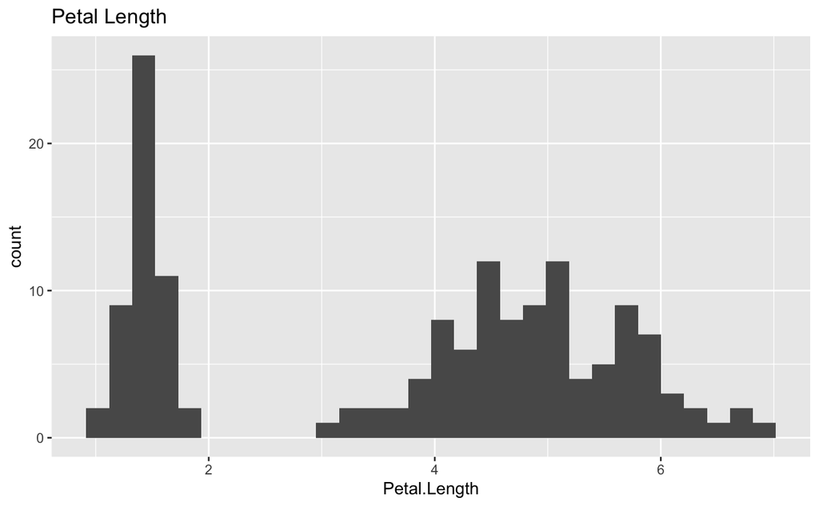

```r
ggplot(data, aes(Petal.Length)) +
  geom_histogram() +
  labs(title = "Petal Length")
```

Now I will explore the connection between variables, starting with petal length and sepal length. I will start with a correlation table:

```r
cor(data[,1:4])
```

```
             Sepal.Length Sepal.Width Petal.Length Petal.Width
Sepal.Length    1.0000000  -0.1175698    0.8717538   0.8179411
Sepal.Width    -0.1175698   1.0000000   -0.4284401  -0.3661259
Petal.Length    0.8717538  -0.4284401    1.0000000   0.9628654
Petal.Width     0.8179411  -0.3661259    0.9628654   1.0000000
```

According to this, there is a strong correlation between Petal length and width and sepal length. I wan to visualize this now, starting with both length variables:

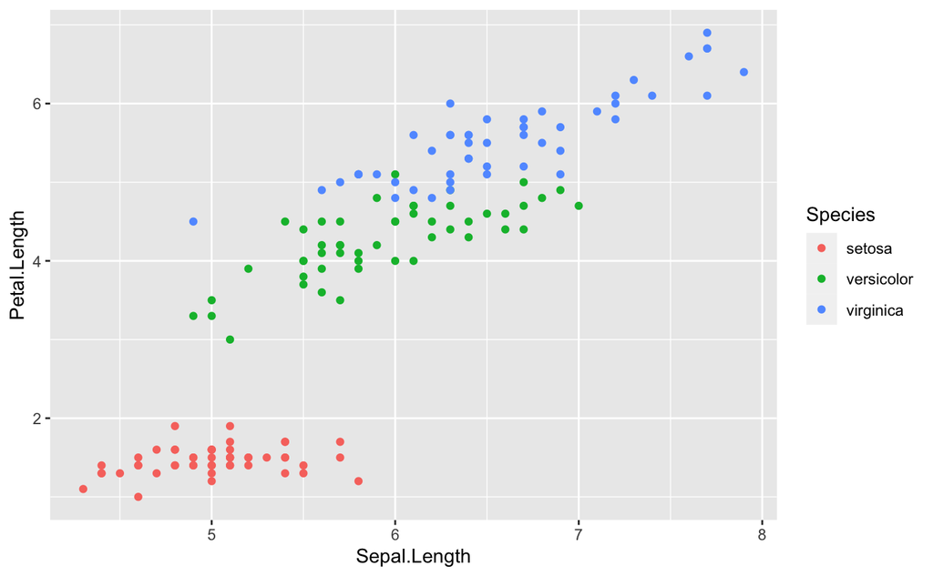

```r
ggplot(data, aes(Sepal.Length, Petal.Length, color = Species)) +
  geom_point()
```

And now, looking at Petal Width vs sepal length

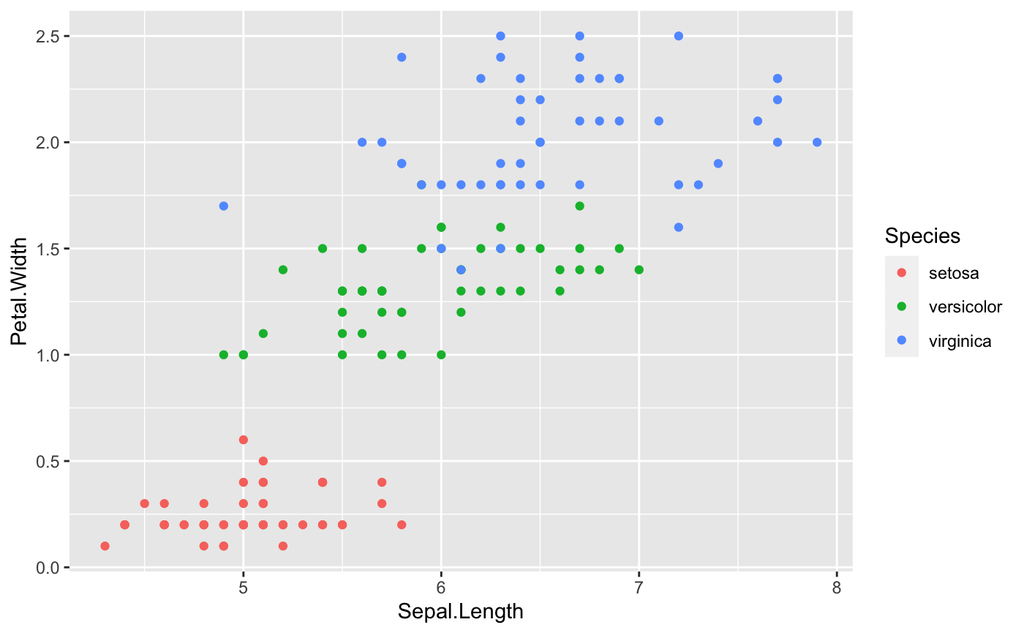

```r
ggplot(data, aes(Sepal.Length, Petal.Width, color = Species)) +
  geom_point()
```

Looking at these graphs, it appears that there is a connection between petal and sepal length but appears to be more so present for versicolor and virginica and not so much for setosa and is more so present when comparing sepal length to petal length.

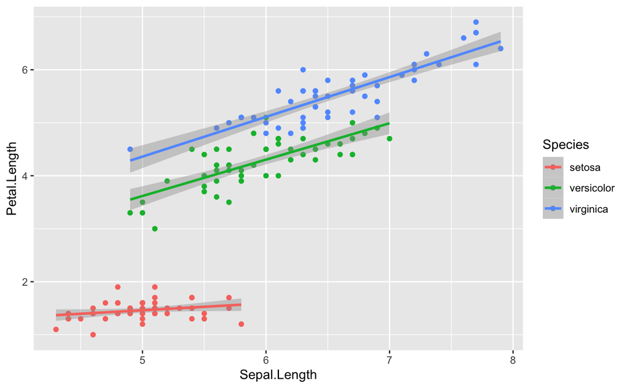

```r
ggplot(data, aes(Sepal.Length, Petal.Length, color = Species)) +
  geom_point() +
  geom_smooth(method = "lm")
```

Adding a trend line, demonstrates this further with petal and sepal length more connected with versicolor and virginica.